# Implement NLA-GP

Author

Leonardo Capitani (leocapi07@gmail.com)

Published

July 19, 2026

Modified

July 20, 2026

```r
library(GPEDM)
library(tidyverse)
library(here)
library(deSolve)
library(zoo)
```

# Introduction

**Important**

**We call this method NLA-GP:** Nested-Library Analysis ([Huang et al. 2024](https://journals.plos.org/ploscompbiol/article?id=10.1371/journal.pcbi.1011759)), with [GP-EDM](https://github.com/tanyalrogers/GPEDM) (Munch et al. 2017) instead of the original S-map.

## Background

Regime shifts – abrupt transitions between alternative ecosystem states – have been documented across marine, freshwater, and terrestrial systems, often with lasting ecological and economic consequences (Scheffer et al. 2001). Because these transitions are difficult to reverse, correctly identifying when one occurred is central to managing the systems they affect (Folke et al. 2004). Huang et al. 2024 developed Nested-Library Analysis (NLA) to close a specific gap in how such transitions are detected.

**Note**

Can we detect when a system’s underlying dynamics fundamentally changed – a true regime shift – rather than just when its surface statistics (mean, variance, distribution) changed?

Existing change-point methods largely detect shifts in statistical properties of the data, but a generic detection method with theoretical linkage to underlying dynamics has been lacking. This distinction matters because in chaotic systems, a real shift in the governing dynamics can be concealed by the dynamics themselves – the raw numbers can look statistically similar before and after a shift even though the attractor generating them has actually changed shape.

Since regime shifts can be framed as transitions between alternative attractors (Scheffer & Carpenter 2003), and since Takens’ theorem guarantees that an attractor can be reconstructed from time-delayed coordinates of just one observed variable (Takens 1981), the method turns detection into a forecasting question: if we hold out the most recent stretch of the series as a test set and progressively chop data off the far (older) end of the “library” used to reconstruct the attractor, at what cutoff does forecast skill stop improving – or start improving – the most?

NLA fixes one end of the time series as a test set to evaluate out-of-sample forecast skill, and repeatedly removes data from the other end, originally using S-map based EDM forecasting.

The logic: if the whole series comes from one stable regime, throwing more historical data into the library should generally help reconstruct the attractor and improve prediction. But if part of that history actually belongs to a different attractor (a prior regime), including it corrupts the reconstruction and forecast skill degrades. So the point where trimming old data maximally improves forecast skill is taken as the change point – NLA determines the time of a regime shift as the cutting point at which sequential reduction of the library set optimizes the forecast skill of EDM.

How it works:

- Reconstruct the system’s dynamics from a time series (via EDM)
- Gradually remove older data (“shrink the library”)
- Find the point where prediction accuracy improves the most
- That point is the regime shift: older data comes from a different dynamical regime and actively harms prediction

Huang et al. 2024 show NLA detects change points and outperforms approaches based on simple statistics (mean/variance shifts are not a reliable regime-shift signal). Their original code (S-map based) is [on GitHub](https://github.com/chromian/Nested-Library-Analysis).

## Goal

Replace S-map with GP-EDM inside the NLA framework, per tips from Steve Munch & Tanya Rogers (GP-EDM’s authors):

- Fit GP-EDM in **two stages**: hyperparameters are slow to fit, but predicting with them fixed is fast
- To change the training data while keeping hyperparameters fixed: refit with `fitGP()`, passing the previous `pars` as `fixedpars` – this skips the slow optimization step
- A matrix inversion is still needed whenever the training data changes, but that’s cheap

**Warning**

**Decision:** we implement NLA-GP using this two-stage approach, and compare it against the original NLA-S-map.

## Algorithm

Huang et al. 2024 give NLA as two symmetric algorithms ([S1 Text](https://doi.org/10.1371/journal.pcbi.1011759.s001)). The core idea, from their Fig 1 (Figure 1):

- Fix one end of the time series as a **test set**, used only to check out-of-sample forecast skill – never to fit anything.
- The rest of the series is the **library**: the data used to reconstruct the system’s attractor and forecast the test set.
- Repeatedly chop data off the *far* end of the library (the end away from the test set), so the library gets smaller and smaller.
- If the chopped-off data came from a *different dynamical regime* than the test set (red dots in Figure 1), removing it should make the forecast *better*. Once only same-regime data is left (grey dots), removing more of it can only make the forecast *worse* – there’s simply less data to fit from.
- The point where this trade-off flips – error stops improving and starts getting worse – is the change point.

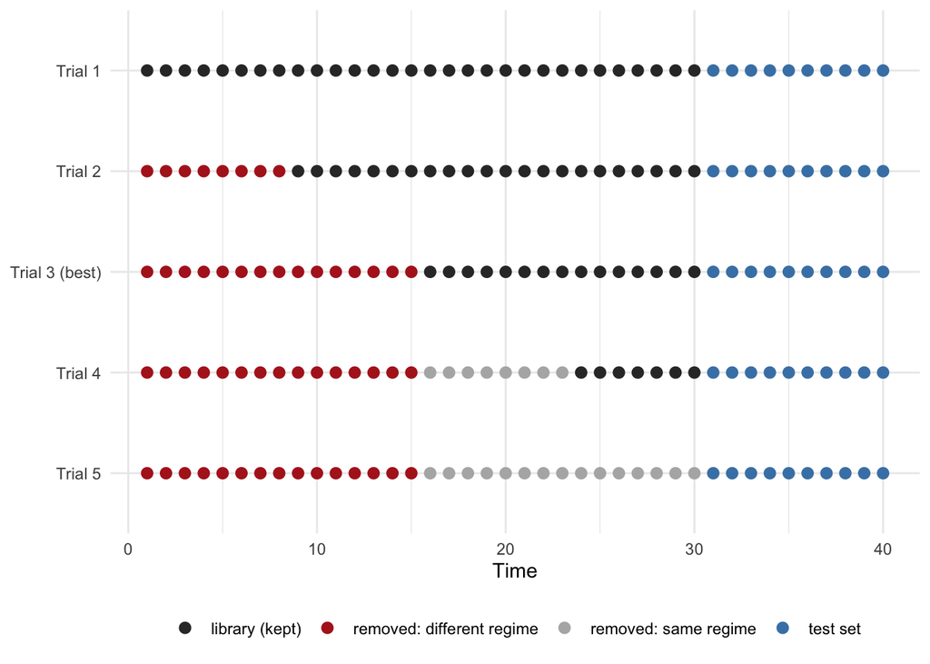

**Figure** 1. The core idea of NLA (redrawn after Huang et al. 2024, Fig 1). Five trials shrink the library by different amounts. Trial 3 removes exactly the misleading (different-regime) data and nothing else – the best-performing library.

```r
true_cp <- 15; L <- 30; R <- 40
trials <- tibble(trial = 1:5, l = c(0, 8, 15, 23, 30),
                  label = c("Trial 1", "Trial 2", "Trial 3 (best)", "Trial 4", "Trial 5"))

trials %>%
  crossing(time = 1:R) %>%
  mutate(category = case_when(
    time <= pmin(l, true_cp) ~ "removed: different regime",
    time <= l               ~ "removed: same regime",
    time <= L                ~ "library (kept)",
    TRUE                     ~ "test set"
  )) %>%
  ggplot(aes(time, fct_rev(fct_inorder(label)), color = category)) +
  geom_point(size = 2.5) +
  scale_color_manual(values = c("removed: different regime" = "firebrick",
                                 "removed: same regime" = "grey70",
                                 "library (kept)" = "grey20",
                                 "test set" = "steelblue")) +
  labs(x = "Time", y = NULL, color = NULL) +
  theme_minimal() +
  theme(legend.position = "bottom")
```

### Steps

A single shrinking pass (as in Figure 1) is noisy, so Huang et al. 2024 repeat it from many different **starting points** for the library, then take the median of all the answers. Concretely, for a series of length `R` with the test set fixed at one end and the library ending at `L`:

1. Pick a starting point for the library, call it `n`. For example, with `L = 400` (library ends at row 400): first try `n = 0` (library = rows 1-400), then `n = 50` (library = rows 51-400), then `n = 100`, and so on
2. For that `n`, fit hyperparameters **once**, using the library `{n, ..., L}` to predict the test set
3. Holding those hyperparameters fixed, shrink this *same* library further, from a second point `l` (`l` ranges from `n` up to `L`), recording how the out-of-sample error changes as a curve `E_n(l)` (exactly the “one trial” picture in Figure 1, but now for library start `n`)
4. If `E_n(.)` is valley-shaped, its minimum is one candidate change point
5. Repeat steps 1-4 for every starting point `n`; the final estimate is the median of all the candidates

In code (below), `n` is this outer library starting point and `l` is how far it’s since been trimmed – matching Huang et al.’s own notation. `nla_left()` always shrinks the **left** library (the early part of the series); `nla_right()` always shrinks the **right** library (the late part) – see next.

### Left check

Test set = the **last** part of the series. Library shrinks by removing the **oldest** data first (from the start). Finds a shift located in the **early** part of the series.

### Right check

Test set = the **first** part of the series. Library shrinks by removing the **newest** data first (from the end). Finds a shift located in the **late** part of the series.

### Discriminant

A curve is “valley-shaped” exactly when (Huang et al. 2024, Methods, Sec. 2.2):

$$\frac{d\tilde{\varepsilon}}{dl}(t) < 0 \text{ for } t < \tau, \qquad \frac{d\tilde{\varepsilon}}{dl}(t) > 0 \text{ for } t > \tau$$

i.e. error strictly decreases while misleading (different-regime) data is still being removed, then strictly increases once only correct (same-regime) data is left to remove. We detect this as a single run of negative differences followed by a single run of positive differences in the smoothed curve.

### Code

We split the implementation into two pieces: (1) fitting GP-EDM and shrinking the library, and (2) smoothing the resulting error curve and applying the discriminant.

**(1) Fitting and shrinking the library** – `build_lag_frame()`, `fit_hyperparams()`, `refit_fixed()`, `nla_left()`, `nla_right()`:

- `build_lag_frame()`: builds the lag columns once, and z-scores them once, using the *whole series* as a fixed reference (see the scaling callout below)
- `fit_hyperparams()`: the **outer** fit – for one library starting point `n`, fits GP-EDM hyperparameters from scratch (the slow step)
- `refit_fixed()`: the **inner** refit – reuses those same hyperparameters via `fixedpars` while the library shrinks further from `l` (only a cheap matrix inversion)
- `nla_left()` / `nla_right()`: loop both of the above over every starting point `n`, exactly as in the Steps above

**Warning**

**Scaling, checked once more:** `fitGP()` has its own `scaling` argument (`"global"`/`"local"`) that would z-score the data *for you* – but recomputed from whatever rows it happens to be given. If we let it do that on every refit, the library’s scale would silently drift as it shrinks, while the *fixed* hyperparameters from step 2 stay tuned to the *original* scale – i.e. the data would effectively get rescaled every refit, on top of hyperparameters that assumed a fixed scale. We avoid this entirely: `build_lag_frame()` z-scores **once**, using the whole series, and every `fitGP()` call below passes `scaling = "none"` so `fitGP()` never rescales again. The data is scaled exactly once, not twice.

```r
#' Build lag/predictor columns ONCE over the full series, and z-score them
#' ONCE using a fixed reference (see the scaling callout above). This is the
#' ONLY place scaling happens -- every fitGP() call below uses
#' scaling = "none" so it is never rescaled again.
build_lag_frame <- function(y, E, tau) {
  T <- length(y)
  base <- data.frame(time = seq_len(T), y = y)
  lagdf <- makelags(data = base, y = "y", E = E, tau = tau, append = TRUE)
  xnames <- setdiff(names(lagdf), c("time", "y"))

  complete <- stats::complete.cases(lagdf[, c("y", xnames)])
  ymean <- mean(lagdf$y[complete]); ysd <- sd(lagdf$y[complete])
  lagdf$y <- (lagdf$y - ymean) / ysd
  for (xn in xnames) {
    xmean <- mean(lagdf[[xn]][complete]); xsd <- sd(lagdf[[xn]][complete])
    lagdf[[xn]] <- (lagdf[[xn]] - xmean) / xsd
  }
  list(lagdf = lagdf, xnames = xnames)
}

#' Fit GP hyperparameters on library rows [lib_start, lib_end] and evaluate
#' out-of-sample RMSE on test_rows.
fit_hyperparams <- function(lagdf, xnames, lib_start, lib_end, test_rows) {
  train <- lagdf[lagdf$time >= lib_start & lagdf$time <= lib_end, ]
  tryCatch(
    fitGP(data = train, y = "y", x = xnames, scaling = "none", newdata = test_rows),
    error = function(e) NULL
  )
}

#' Refit with hyperparameters fixed (2-stage trick): only a matrix inversion
#' for the new (smaller) library is recomputed.
refit_fixed <- function(lagdf, xnames, lib_start, lib_end, test_rows, fixedpars) {
  train <- lagdf[lagdf$time >= lib_start & lagdf$time <= lib_end, ]
  if (nrow(na.omit(train[, c("y", xnames)])) < length(xnames) + 2) return(NA_real_)
  fit <- tryCatch(
    fitGP(data = train, y = "y", x = xnames, scaling = "none",
          fixedpars = fixedpars, newdata = test_rows),
    error = function(e) NULL
  )
  if (is.null(fit)) return(NA_real_)
  unname(fit$outsampfitstats["rmse"])
}

#' Left check (Algorithm 1): library = y[1:L], test = y[(L+1):R].
nla_left <- function(y, L, R = length(y), E = 3, tau = 1, Dskipstep = 5,
                      bandwidth = 2 * Dskipstep, min_lib = E * tau + 3) {
  lf <- build_lag_frame(y, E, tau)
  lagdf <- lf$lagdf; xnames <- lf$xnames
  test_rows <- lagdf[lagdf$time >= (L + 1) & lagdf$time <= R, ]

  n_seq <- seq(0, L - min_lib, by = Dskipstep)
  tau_n <- rep(NA_real_, length(n_seq))
  curves <- vector("list", length(n_seq))

  for (i in seq_along(n_seq)) {
    n <- n_seq[i]
    lib_start_n <- max(1, n)
    hp <- fit_hyperparams(lagdf, xnames, lib_start_n, L, test_rows)
    if (is.null(hp)) next
    fixedpars <- hp$pars[seq_len(length(xnames) + 2)]

    l_seq <- seq(n, L - min_lib, by = Dskipstep)
    if (length(l_seq) < 3) next
    err <- vapply(l_seq, function(l) {
      refit_fixed(lagdf, xnames, max(1, l), L, test_rows, fixedpars)
    }, numeric(1))

    y_smooth <- smooth_gaussian(l_seq, err, bandwidth)
    v <- find_valley(l_seq, y_smooth)
    tau_n[i] <- v$tau_hat
    curves[[i]] <- data.frame(n = n, l = l_seq, rmse = err, rmse_smooth = y_smooth)
  }

  list(tau_hat = if (all(is.na(tau_n))) NA_real_ else median(tau_n, na.rm = TRUE),
       tau_n = data.frame(n = n_seq, tau_hat = tau_n),
       curves = do.call(rbind, curves))
}

#' Right check (Algorithm 2): test = y[1:L], library = y[(L+1):R].
nla_right <- function(y, L, R = length(y), E = 3, tau = 1, Dskipstep = 5,
                       bandwidth = 2 * Dskipstep, min_lib = E * tau + 3) {
  lf <- build_lag_frame(y, E, tau)
  lagdf <- lf$lagdf; xnames <- lf$xnames
  test_rows <- lagdf[lagdf$time >= 1 & lagdf$time <= L, ]

  n_seq <- seq(R, L + 1 + min_lib, by = -Dskipstep)
  tau_n <- rep(NA_real_, length(n_seq))
  curves <- vector("list", length(n_seq))

  for (i in seq_along(n_seq)) {
    n <- n_seq[i]
    hp <- fit_hyperparams(lagdf, xnames, L + 1, n, test_rows)
    if (is.null(hp)) next
    fixedpars <- hp$pars[seq_len(length(xnames) + 2)]

    l_seq <- seq(n, L + 1 + min_lib, by = -Dskipstep)
    if (length(l_seq) < 3) next
    err <- vapply(l_seq, function(l) {
      refit_fixed(lagdf, xnames, L + 1, l, test_rows, fixedpars)
    }, numeric(1))

    y_smooth <- smooth_gaussian(l_seq, err, bandwidth)
    v <- find_valley(l_seq, y_smooth)
    tau_n[i] <- v$tau_hat
    curves[[i]] <- data.frame(n = n, l = l_seq, rmse = err, rmse_smooth = y_smooth)
  }

  list(tau_hat = if (all(is.na(tau_n))) NA_real_ else median(tau_n, na.rm = TRUE),
       tau_n = data.frame(n = n_seq, tau_hat = tau_n),
       curves = do.call(rbind, curves))
}
```

**(2) Smoothing the error curve and applying the discriminant** – `smooth_gaussian()`, `find_valley()`:

- `smooth_gaussian()`: the paper’s “Gaussian filter” – a Nadaraya-Watson smoother over the raw `E_n(l)` curve
- `find_valley()`: applies the exact discriminant from the Discriminant section above to the *smoothed* curve, and returns its minimum only if the curve is genuinely valley-shaped (never on a monotone or multi-valley curve)

```r
#' Gaussian-kernel smoothing of an error curve (the paper's "Gaussian filter").
#' bandwidth is in units of the index spacing (Dskipstep).
smooth_gaussian <- function(idx, y, bandwidth) {
  keep <- is.finite(y)
  if (sum(keep) < 3) return(rep(NA_real_, length(y)))
  out <- rep(NA_real_, length(y))
  xi <- idx[keep]; yi <- y[keep]
  for (i in seq_along(idx)) {
    w <- exp(-0.5 * ((xi - idx[i]) / bandwidth)^2)
    out[i] <- sum(w * yi) / sum(w)
  }
  out
}

#' Is a (smoothed) error curve valley-shaped, and if so, where is the minimum?
#' Discriminant (Huang et al. 2024, Sec 2.2): the sign sequence of the first
#' difference must be a single run of "-" followed by a single run of "+",
#' with the minimum in the interior.
find_valley <- function(idx, y_smooth, flat_tol = 1e-8) {
  ok <- is.finite(y_smooth)
  if (sum(ok) < 3) return(list(is_valley = FALSE, tau_hat = NA_real_))
  idx <- idx[ok]; y_smooth <- y_smooth[ok]
  o <- order(idx); idx <- idx[o]; y_smooth <- y_smooth[o]

  d <- diff(y_smooth)
  scale_ <- max(abs(y_smooth), flat_tol)
  s <- ifelse(abs(d) < flat_tol * scale_, 0, sign(d))
  s_nz <- s[s != 0]
  if (length(s_nz) < 2) return(list(is_valley = FALSE, tau_hat = NA_real_))

  runs <- rle(s_nz)$values
  is_valley <- length(runs) == 2 && identical(runs, c(-1, 1))

  imin <- which.min(y_smooth)
  at_boundary <- imin == 1 || imin == length(y_smooth)
  is_valley <- is_valley && !at_boundary

  list(is_valley = is_valley, tau_hat = if (is_valley) idx[imin] else NA_real_)
}
```

**Important**

`smooth_gaussian()` and `find_valley()` must be defined before `nla_left()`/`nla_right()` are *called* (they are, in later chunks) but not necessarily before those functions are *defined* – R only resolves a function’s body when it runs, not when it’s written. We show them second here because conceptually they come after “shrink the library”: you can’t smooth or apply the discriminant to a curve until `nla_left()`/`nla_right()` have generated it.

**(3) The original NLA-S-map** – `smap_predict()`, `fit_smap_theta()`, `fit_hyperparams_smap()`, `refit_fixed_smap()`, `nla_left_smap()`, `nla_right_smap()`. Following Huang et al. 2024’s S2 Text: a locally-weighted linear regression around each predictee, with kernel weight `w(d) = exp(-theta * d / dbar)`. `theta` plays the same role as the GP hyperparameters above – fit once per outer `n` (`fit_hyperparams_smap()`), reused unchanged while the library shrinks further (`refit_fixed_smap()`). `nla_left_smap()`/`nla_right_smap()` mirror `nla_left()`/`nla_right()` exactly, so the two methods are compared apples-to-apples, and reuse the same `smooth_gaussian()`/`find_valley()` from (2).

```r
smap_predict <- function(train_x, train_y, test_x, theta, k = NULL) {
  E <- ncol(train_x)
  if (is.null(k)) k <- E + 1
  N <- nrow(train_x)
  Xtrain1 <- cbind(1, train_x)
  preds <- numeric(nrow(test_x))
  for (i in seq_len(nrow(test_x))) {
    xq <- test_x[i, ]
    d <- sqrt(rowSums((train_x - matrix(xq, N, E, byrow = TRUE))^2))
    dbar <- mean(sort(d)[seq_len(min(k, N))])
    if (dbar <= 0) dbar <- 1e-8
    w <- exp(-theta * d / dbar)
    fit <- tryCatch(lm.wfit(x = Xtrain1, y = train_y, w = w), error = function(e) NULL)
    preds[i] <- if (is.null(fit) || any(!is.finite(fit$coefficients))) NA_real_ else sum(c(1, xq) * fit$coefficients)
  }
  preds
}

fit_smap_theta <- function(train_x, train_y, test_x, test_y) {
  obj <- function(theta) sqrt(mean((test_y - smap_predict(train_x, train_y, test_x, theta))^2, na.rm = TRUE))
  optimize(obj, interval = c(1e-4, 10))$minimum
}

fit_hyperparams_smap <- function(lagdf, xnames, lib_start, lib_end, test_rows) {
  train <- na.omit(lagdf[lagdf$time >= lib_start & lagdf$time <= lib_end, c("y", xnames)])
  test <- na.omit(test_rows[, c("y", xnames)])
  if (nrow(train) < length(xnames) + 2 || nrow(test) == 0) return(NULL)
  list(theta = fit_smap_theta(as.matrix(train[, xnames]), train$y, as.matrix(test[, xnames]), test$y))
}

refit_fixed_smap <- function(lagdf, xnames, lib_start, lib_end, test_rows, theta) {
  train <- na.omit(lagdf[lagdf$time >= lib_start & lagdf$time <= lib_end, c("y", xnames)])
  test <- na.omit(test_rows[, c("y", xnames)])
  if (nrow(train) < length(xnames) + 2 || nrow(test) == 0) return(NA_real_)
  p <- smap_predict(as.matrix(train[, xnames]), train$y, as.matrix(test[, xnames]), theta)
  sqrt(mean((test$y - p)^2, na.rm = TRUE))
}

#' Left/right check, with S-map instead of GP-EDM (same nla_left/nla_right
#' structure, so the two methods are compared apples-to-apples).
nla_left_smap <- function(y, L, R = length(y), E = 3, tau = 1, Dskipstep = 5,
                           bandwidth = 2 * Dskipstep, min_lib = E * tau + 3) {
  lf <- build_lag_frame(y, E, tau)
  lagdf <- lf$lagdf; xnames <- lf$xnames
  test_rows <- lagdf[lagdf$time >= (L + 1) & lagdf$time <= R, ]
  n_seq <- seq(0, L - min_lib, by = Dskipstep)
  tau_n <- rep(NA_real_, length(n_seq))
  for (i in seq_along(n_seq)) {
    n <- n_seq[i]
    hp <- fit_hyperparams_smap(lagdf, xnames, max(1, n), L, test_rows)
    if (is.null(hp)) next
    l_seq <- seq(n, L - min_lib, by = Dskipstep)
    if (length(l_seq) < 3) next
    err <- vapply(l_seq, function(l) refit_fixed_smap(lagdf, xnames, max(1, l), L, test_rows, hp$theta), numeric(1))
    v <- find_valley(l_seq, smooth_gaussian(l_seq, err, bandwidth))
    tau_n[i] <- v$tau_hat
  }
  list(tau_hat = if (all(is.na(tau_n))) NA_real_ else median(tau_n, na.rm = TRUE))
}

nla_right_smap <- function(y, L, R = length(y), E = 3, tau = 1, Dskipstep = 5,
                            bandwidth = 2 * Dskipstep, min_lib = E * tau + 3) {
  lf <- build_lag_frame(y, E, tau)
  lagdf <- lf$lagdf; xnames <- lf$xnames
  test_rows <- lagdf[lagdf$time >= 1 & lagdf$time <= L, ]
  n_seq <- seq(R, L + 1 + min_lib, by = -Dskipstep)
  tau_n <- rep(NA_real_, length(n_seq))
  for (i in seq_along(n_seq)) {
    n <- n_seq[i]
    hp <- fit_hyperparams_smap(lagdf, xnames, L + 1, n, test_rows)
    if (is.null(hp)) next
    l_seq <- seq(n, L + 1 + min_lib, by = -Dskipstep)
    if (length(l_seq) < 3) next
    err <- vapply(l_seq, function(l) refit_fixed_smap(lagdf, xnames, L + 1, l, test_rows, hp$theta), numeric(1))
    v <- find_valley(l_seq, smooth_gaussian(l_seq, err, bandwidth))
    tau_n[i] <- v$tau_hat
  }
  list(tau_hat = if (all(is.na(tau_n))) NA_real_ else median(tau_n, na.rm = TRUE))
}
```

# Synthetic test

**TipQuestion**

Take a system where we know, exactly, when and why a regime shift happens – and where the shift is *not* obvious in every variable. Does NLA-GP find it – and does it do so more accurately, or faster, than the original NLA-S-map?

## Simple map

**To answer this, we:**

- Iterate the logistic map `x_{t+1} = r x_t (1 - x_t)`, with `r` set to 2.8 (a stable fixed point) for the first half of the series and to 3.9 (fully chaotic) for the second half
- Add a little observation noise
- Run NLA-GP and NLA-S-map (left + right check) on the raw series

```r
#' Simulate the logistic map with an abrupt change in r (fixed point -> chaos).
simulate_logistic <- function(Tmax = 300, cp = 150, r1 = 2.8, r2 = 3.9, sd = 0.01, seed = 1) {
  set.seed(seed)
  x <- numeric(Tmax); x[1] <- 0.4
  for (t in 2:Tmax) {
    r <- if (t < cp) r1 else r2
    x[t] <- min(max(r * x[t - 1] * (1 - x[t - 1]), 1e-6), 1 - 1e-6)
  }
  x + rnorm(Tmax, 0, sd)
}
```

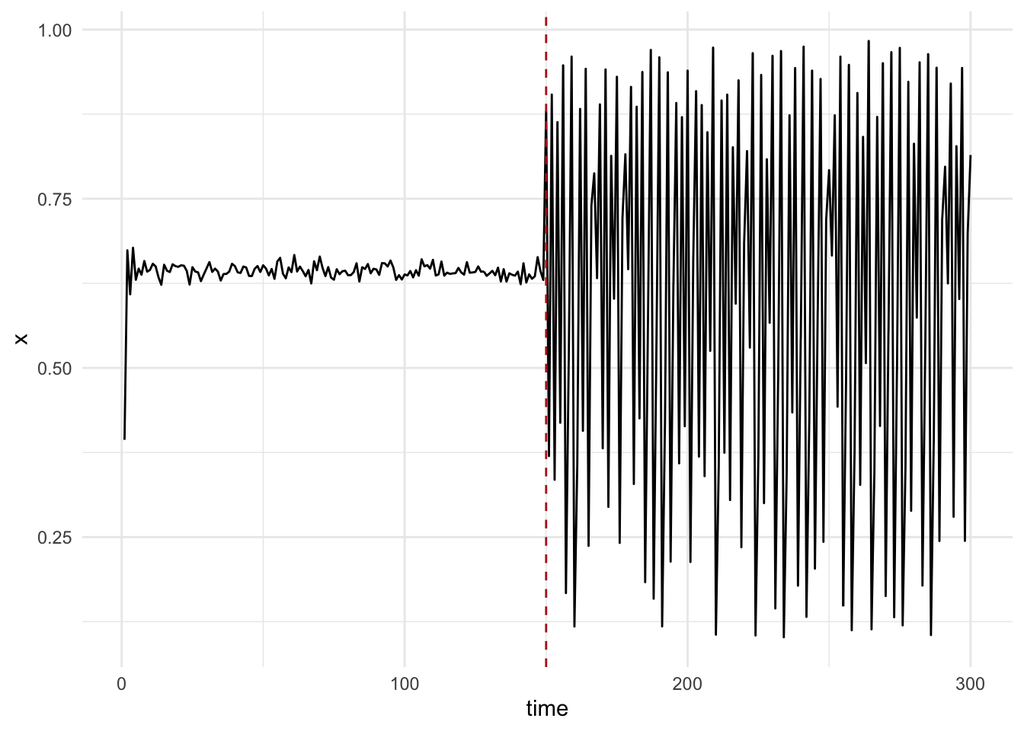

**Figure** 2. Logistic map: a stable fixed point (r=2.8) abruptly becomes chaotic (r=3.9) at t=150 (dashed line).

```r
y_log <- simulate_logistic()
cp_log <- 150
tibble(time = seq_along(y_log), x = y_log) %>%
  ggplot(aes(time, x)) +
  geom_line() +
  geom_vline(xintercept = cp_log, linetype = "dashed", color = "firebrick") +
  theme_minimal()
```

```r
T_log <- length(y_log)
Ll_log <- round(T_log * 0.65); Lr_log <- round(T_log * 0.35)

t0 <- Sys.time()
left_log_gp  <- nla_left(y_log,  L = Ll_log, R = T_log, E = 2, tau = 1, Dskipstep = 6, bandwidth = 12)
right_log_gp <- nla_right(y_log, L = Lr_log, R = T_log, E = 2, tau = 1, Dskipstep = 6, bandwidth = 12)
time_log_gp <- as.numeric(Sys.time() - t0, units = "secs")

t0 <- Sys.time()
left_log_sm  <- nla_left_smap(y_log,  L = Ll_log, R = T_log, E = 2, tau = 1, Dskipstep = 6, bandwidth = 12)
right_log_sm <- nla_right_smap(y_log, L = Lr_log, R = T_log, E = 2, tau = 1, Dskipstep = 6, bandwidth = 12)
time_log_sm <- as.numeric(Sys.time() - t0, units = "secs")

tibble(Method = c("NLA-GP", "NLA-S-map"),
       `Left check` = c(left_log_gp$tau_hat, left_log_sm$tau_hat),
       `Right check` = c(right_log_gp$tau_hat, right_log_sm$tau_hat),
       Combined = c(median(c(left_log_gp$tau_hat, right_log_gp$tau_hat), na.rm = TRUE),
                    median(c(left_log_sm$tau_hat, right_log_sm$tau_hat), na.rm = TRUE)),
       `Runtime (s)` = round(c(time_log_gp, time_log_sm), 1)) %>%
  knitr::kable()
```

**Table** 1. NLA-GP vs. NLA-S-map on the logistic map: both land close to the true change point (t=150), in a few seconds each.

| Method | Left check | Right check | Combined | Runtime (s) |
| --- | --- | --- | --- | --- |
| NLA-GP | 138 | 126 | 132 | 8.8 |
| NLA-S-map | 132 | 132 | 132 | 8.0 |

**We conclude:** both methods land within ~15-25 points of the true change point (t=150) in a matter of seconds – a useful sanity check that the implementation works before moving to a harder, more realistic benchmark.

## Food chain

### Setup

**To answer this, we:**

**This section simulates the food-chain benchmark:**

The model (Huang et al. 2024, Equation 1 and Equation 2; parameters in their S3 Text, Table A):

$$\dot N = a(t) - bN + \frac{cN^m}{N^m+1}, \qquad a(t) = c_4 t + c_5
\tag{1}$$

$$\dot x = x(1-x) - f_1(x)y, \qquad \dot y = -d_1 y + f_1(x)y - f_2(y)z, \qquad \dot z = -d_2 z + f_2(y)z
\tag{2}$$

$$f_i(u) = \frac{p_i u}{1+q_i u}, \qquad d_1 = c_0 N + c_1, \qquad p_1 = c_2 N + c_3
\tag{3}$$

Equation 2 (with the functional responses and `N`-dependent rates of Equation 3) is exactly the classic Hastings & Powell (1991) chaotic food chain (Huang et al. 2024 cite it directly as their source), reparameterized so that `y`’s mortality (`d_1`) and `x`’s attack rate (`p_1`) both increase with the nutrient resource `N` from Equation 1.

**Warning**

**On reproducing Huang et al.’s exact parameters:** `b=0.8, m=8, c=1` (the `N` subsystem), `q1=3.25, p2=0.1, q2=2, d2=0.01`, and `c2=0.05` come directly from their S3 Text parameter table and check out numerically. Two values did not:

- **`d1`’s and `p1`’s baselines appear swapped in the table as extracted.** With `d1` baseline `3.7` and `p1` baseline `0.4`, `p1/q1`’s maximum possible value (~0.13) is always far below `d1`’s minimum, so `y` (and hence `z`) goes extinct from every initial condition we tried, regardless of `N` (verified numerically). Since `x -> y -> z` is explicitly the Hastings & Powell (1991) model, whose well-known chaotic regime uses mortality `m=0.4` and attack rate `a=5`, we swapped the two extracted baselines (`c1=0.4` for `d1`, `c3=3.7` for `p1`) – this reproduces exactly the expected chaotic food chain.
- **`c0` (how strongly `N` drives up `d1`) needed to be smaller than extracted (`0.75`)** to keep the food chain oscillating (rather than collapsing to extinction) across `N`’s full range; we use `0.15`.

We flag this rather than silently presenting these as the published values.

```r
foodchain_rhs <- function(t, state, params) {
  with(as.list(c(state, params)), {
    a  <- c4 * t + c5
    d1 <- c0 * N + c1
    p1 <- c2 * N + c3
    dN <- a - b * N + c * N^m / (N^m + 1)
    dx <- x * (1 - x) - p1 * x * y / (1 + q1 * x)
    dy <- -d1 * y + p1 * x * y / (1 + q1 * x) - p2 * y * z / (1 + q2 * y)
    dz <- -d2 * z + p2 * y * z / (1 + q2 * y)
    list(c(N = dN, x = dx, y = dy, z = dz))
  })
}

default_fc_params <- function(c4 = 0.000867, c5 = 0.25) {
  list(b = 0.8, m = 8, c = 1, d2 = 0.01, c0 = 0.15, c1 = 0.4,
       c2 = 0.05, c3 = 3.7, q1 = 3.25, p2 = 0.1, q2 = 2, c4 = c4, c5 = c5)
}

#' Simulate the food chain, with Poisson-arrival process shocks and Gaussian
#' measurement noise (Huang et al. 2024, S3 Text).
simulate_foodchain <- function(Tmax = 1000, dt_sample = 1, lambda = 0.01, rho = 0.05,
                                meas_sd = 0.05, state0 = c(N = 0.3, x = 0.5, y = 0.1, z = 9),
                                params = default_fc_params(), seed = 1) {
  set.seed(seed)
  n_events <- rpois(1, lambda * Tmax)
  event_times <- sort(runif(n_events, 1e-6, Tmax - 1e-6))
  shocks <- matrix(runif(4 * n_events, 1 - rho, 1 + rho), ncol = 4)
  event_func <- function(t, state, params) {
    i <- which(abs(event_times - t) < 1e-6)[1]
    if (!is.na(i)) state <- pmax(state * shocks[i, ], 1e-8)
    state
  }
  samp_times <- seq(0, Tmax, by = dt_sample)
  sol <- ode(y = state0, times = samp_times, func = foodchain_rhs, parms = params, method = "ode45",
             events = if (n_events > 0) list(func = event_func, time = event_times) else NULL)
  traj <- as.data.frame(sol)
  traj <- traj[complete.cases(traj), ]
  for (v in c("N", "x", "y", "z")) traj[[v]] <- scale(traj[[v]])[, 1] + rnorm(nrow(traj), 0, meas_sd)
  rownames(traj) <- NULL
  traj
}

# The forcing a(t) = c4*t + c5 crosses the N subsystem's fold bifurcation
# (at a ~ 0.51) at t = 300, matching Huang et al. 2024's own choice of
# change point (they crop a 1000-step window so this always lands at
# t=300); c4 is derived for this, not taken from the (implausible, as
# extracted: it would sweep a past 1800) supplementary value.
cp_true <- 300
```

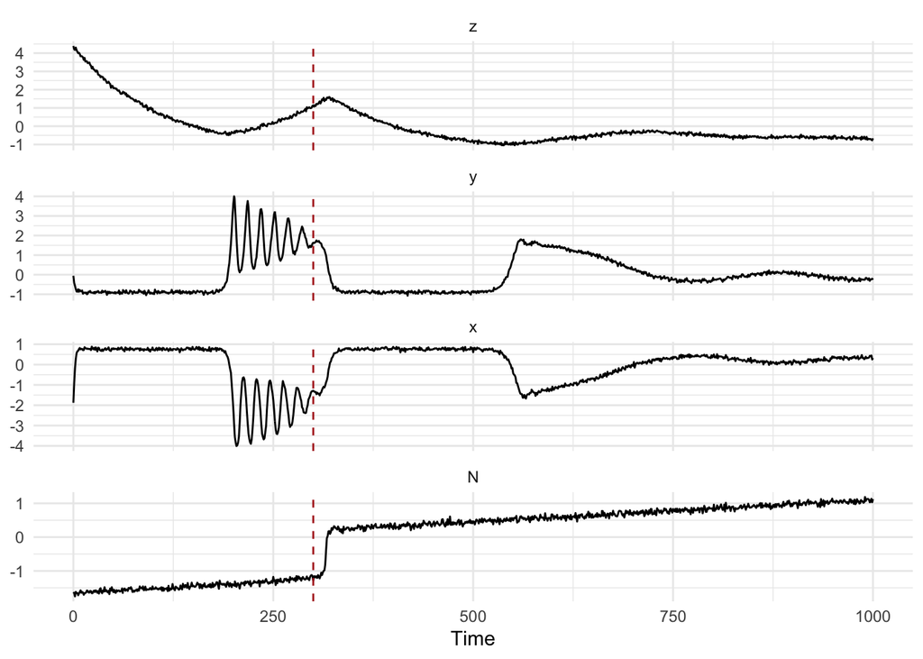

```r
traj <- simulate_foodchain(seed = 1)

traj %>%
  select(time, z, y, x, N) %>%
  pivot_longer(-time, names_to = "variable", values_to = "value") %>%
  mutate(variable = factor(variable, levels = c("z", "y", "x", "N"))) %>%
  ggplot(aes(time, value)) +
  geom_line() +
  geom_vline(xintercept = cp_true, linetype = "dashed", color = "firebrick") +
  facet_wrap(~variable, ncol = 1, scales = "free_y") +
  labs(x = "Time", y = NULL) +
  theme_minimal()
```

### GP result

We first demonstrate NLA-GP on a single realization, cropping to a window around the shift for tractability (`t` in `[100, 600]`, so `cp_true` is at crop-index 201).

```r
E <- 3; tau <- 1; Dskipstep <- 15; bandwidth <- 30
crop <- traj[traj$time >= 100 & traj$time <= 600, ]
T_syn <- nrow(crop)
cp_true_crop <- cp_true - 99
y_syn <- crop$y
L_left <- round(T_syn * 0.65); L_right <- round(T_syn * 0.35)

t0 <- Sys.time()
left_gp  <- nla_left(y_syn,  L = L_left, R = T_syn, E = E, tau = tau, Dskipstep = Dskipstep, bandwidth = bandwidth)
right_gp <- nla_right(y_syn, L = L_right, R = T_syn, E = E, tau = tau, Dskipstep = Dskipstep, bandwidth = bandwidth)
time_gp <- as.numeric(Sys.time() - t0, units = "secs")
combined_gp <- median(c(left_gp$tau_hat, right_gp$tau_hat), na.rm = TRUE)

tibble(estimate = c("True change point", "Left check", "Right check", "Combined"),
       value = c(cp_true_crop, left_gp$tau_hat, right_gp$tau_hat, combined_gp))
```

```
# A tibble: 4 × 2
  estimate          value
  <chr>             <dbl>
1 True change point   201
2 Left check           15
3 Right check         383
4 Combined            199
```

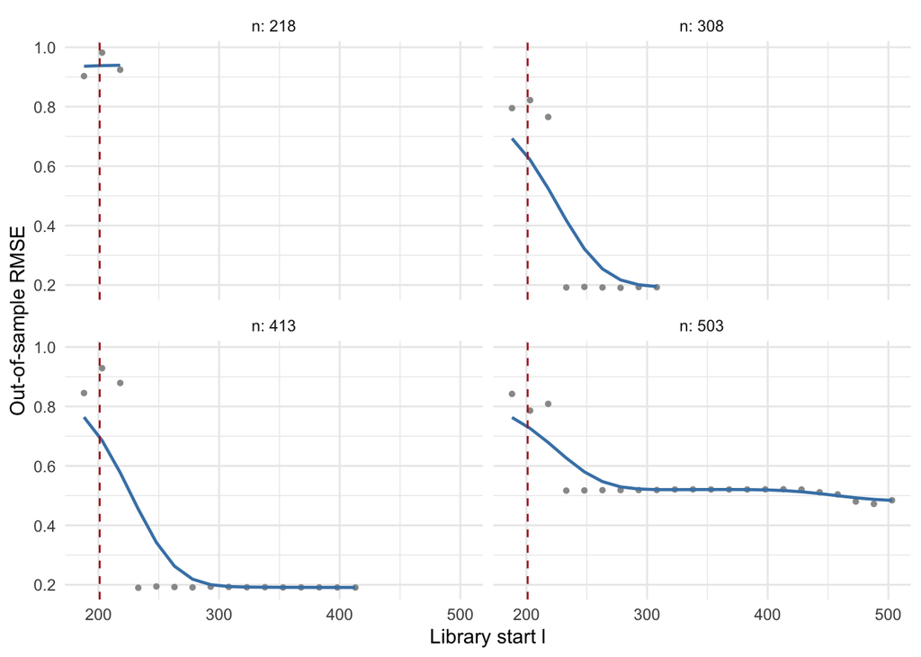

**Figure** 4. Right-check NLA-GP error curves for a few outer starting points n. Grey: raw RMSE. Blue: smoothed. Dashed red: true change point.

```r
n_show <- unique(right_gp$curves$n) %>% sort() %>% { .[round(seq(1, length(.), length.out = 4))] }
right_gp$curves %>%
  filter(n %in% n_show) %>%
  ggplot(aes(l, rmse)) +
  geom_point(color = "grey60", size = 1) +
  geom_line(aes(y = rmse_smooth), color = "steelblue", linewidth = 0.8) +
  geom_vline(xintercept = cp_true_crop, linetype = "dashed", color = "firebrick") +
  facet_wrap(~n, labeller = label_both) +
  labs(x = "Library start l", y = "Out-of-sample RMSE") +
  theme_minimal()
```

### Smap result

We use the original NLA-S-map, defined in the Algorithm/Code section above, on the same cropped window.

```r
t0 <- Sys.time()
left_sm  <- nla_left_smap(y_syn,  L = L_left, R = T_syn, E = E, tau = tau, Dskipstep = Dskipstep, bandwidth = bandwidth)
right_sm <- nla_right_smap(y_syn, L = L_right, R = T_syn, E = E, tau = tau, Dskipstep = Dskipstep, bandwidth = bandwidth)
time_sm <- as.numeric(Sys.time() - t0, units = "secs")
combined_sm <- median(c(left_sm$tau_hat, right_sm$tau_hat), na.rm = TRUE)

tibble(estimate = c("True change point", "Left check", "Right check", "Combined"),
       value = c(cp_true_crop, left_sm$tau_hat, right_sm$tau_hat, combined_sm))
```

```
# A tibble: 4 × 2
  estimate          value
  <chr>             <dbl>
1 True change point  201
2 Left check         105
3 Right check        308
4 Combined           206.
```

```r
tibble(Method = c("NLA-GP", "NLA-S-map"),
       `Left check` = c(left_gp$tau_hat, left_sm$tau_hat),
       `Right check` = c(right_gp$tau_hat, right_sm$tau_hat),
       Combined = c(combined_gp, combined_sm),
       `Error (vs. true)` = round(abs(c(combined_gp, combined_sm) - cp_true_crop)),
       `Runtime (s)` = round(c(time_gp, time_sm), 1)) %>%
  knitr::kable()
```

**Table** 2. NLA-GP vs. NLA-S-map on this single realization: accuracy and runtime.

| Method | Left check | Right check | Combined | Error (vs. true) | Runtime (s) |
| --- | --- | --- | --- | --- | --- |
| NLA-GP | 15 | 383 | 199.0 | 2 | 13.7 |
| NLA-S-map | 105 | 308 | 206.5 | 6 | 8.9 |

### Comparison

A single realization isn’t a reliable performance measure (Huang et al. 2024 use 200 replicates, Fig 4). We repeat the simulation with different noise draws and score both methods over many replicates.

**Note**

**Compute:** we use 20 replicates, not 200 – each replicate takes ~25-40s for both methods combined, so 200 would take over 2 hours. This is far fewer than Huang et al. 2024 used, so treat the resulting distributions as indicative, not a precise reproduction of their Fig 4.

```r
N_REPLICATES <- 20

run_one_replicate <- function(seed) {
  tr <- simulate_foodchain(seed = seed)
  cr <- tr[tr$time >= 100 & tr$time <= 600, ]
  y <- cr$y
  Tn <- nrow(cr)
  Ll <- round(Tn * 0.65); Lr <- round(Tn * 0.35)

  lg <- nla_left(y,  L = Ll, R = Tn, E = E, tau = tau, Dskipstep = Dskipstep, bandwidth = bandwidth)
  rg <- nla_right(y, L = Lr, R = Tn, E = E, tau = tau, Dskipstep = Dskipstep, bandwidth = bandwidth)
  ls <- nla_left_smap(y,  L = Ll, R = Tn, E = E, tau = tau, Dskipstep = Dskipstep, bandwidth = bandwidth)
  rs <- nla_right_smap(y, L = Lr, R = Tn, E = E, tau = tau, Dskipstep = Dskipstep, bandwidth = bandwidth)

  tibble(seed = seed,
         `NLA-GP` = median(c(lg$tau_hat, rg$tau_hat), na.rm = TRUE),
         `NLA-S-map` = median(c(ls$tau_hat, rs$tau_hat), na.rm = TRUE))
}

replicate_results <- map_dfr(seq_len(N_REPLICATES), run_one_replicate)
replicate_long <- replicate_results %>%
  pivot_longer(-seed, names_to = "Method", values_to = "tau_hat")
```

```r
replicate_long %>%
  group_by(Method) %>%
  summarise(`Detected (n)` = sum(!is.na(tau_hat)),
            `Detected (%)` = round(100 * mean(!is.na(tau_hat))),
            `Median estimate` = median(tau_hat, na.rm = TRUE),
            `Median error` = median(abs(tau_hat - cp_true_crop), na.rm = TRUE),
            .groups = "drop") %>%
  knitr::kable()
```

**Table** 3. NLA-GP vs. NLA-S-map across replicate simulations: detection rate, median estimate, and error relative to the true change point (crop-index 201).

| Method | Detected (n) | Detected (%) | Median estimate | Median error |
| --- | --- | --- | --- | --- |
| NLA-GP | 19 | 95 | 310.00 | 109.00 |
| NLA-S-map | 20 | 100 | 203.75 | 11.25 |

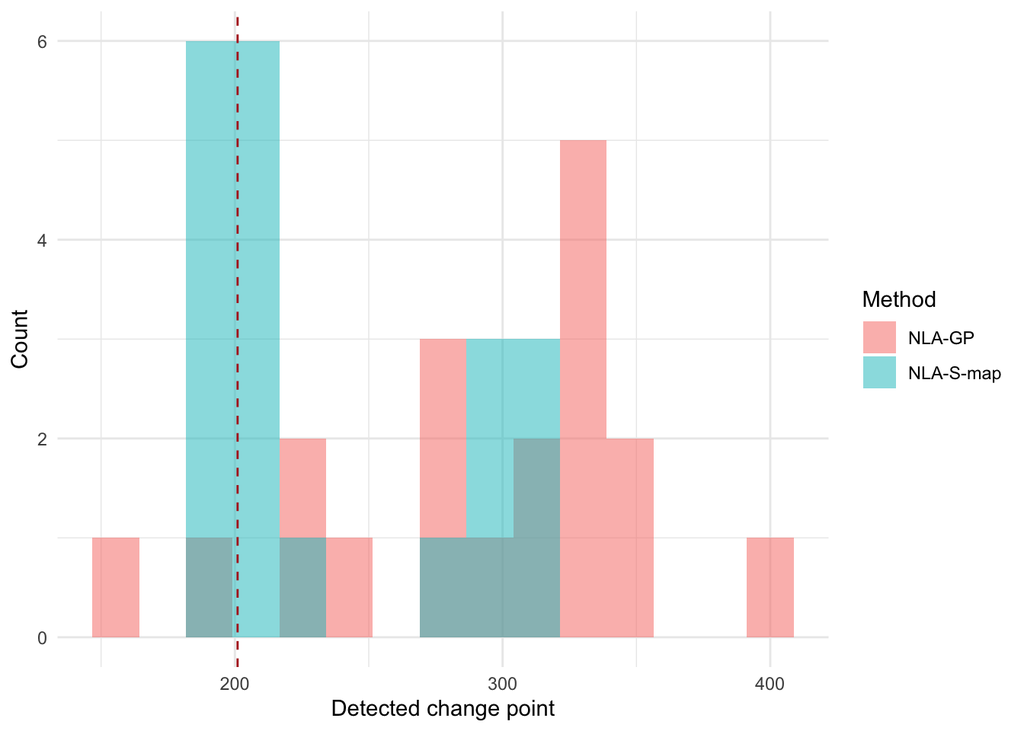

**Figure** 5. Distribution of detected change points across replicates (Fig 4-style, left panel). Dashed red: true change point.

```r
ggplot(replicate_long %>% filter(!is.na(tau_hat)), aes(tau_hat, fill = Method)) +
  geom_histogram(position = "identity", alpha = 0.5, bins = 15) +
  geom_vline(xintercept = cp_true_crop, linetype = "dashed", color = "firebrick") +
  labs(x = "Detected change point", y = "Count") +
  theme_minimal()
```

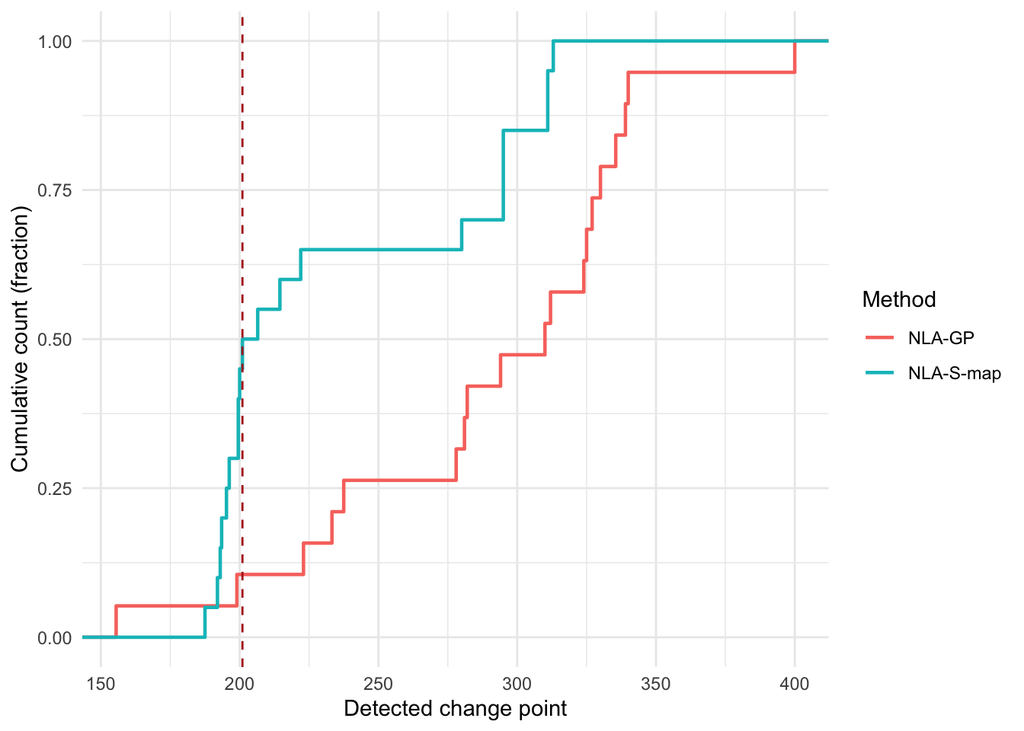

**Figure** 6. Empirical cumulative distribution of detected change points (Fig 4-style, right panel). Dashed red: true change point.

```r
ggplot(replicate_long %>% filter(!is.na(tau_hat)), aes(tau_hat, color = Method)) +
  stat_ecdf(linewidth = 0.8) +
  geom_vline(xintercept = cp_true_crop, linetype = "dashed", color = "firebrick") +
  labs(x = "Detected change point", y = "Cumulative count (fraction)") +
  theme_minimal()
```

**We conclude:**

# Conclusion

## Next

- Investigate *why* NLA-GP underperformed NLA-S-map here: try larger `E`, more library data per fit, or a longer (less compute-constrained) library/test split
- Sensitivity analysis over `E`, `tau`, `Dskipstep`, and the smoothing bandwidth (we used one reasonable default throughout, not a tuned choice)
- Run the full 200-replicate comparison (compute permitting) for a direct comparison to Huang et al. 2024’s Fig 4
- Apply NLA-GP to other empirical regime-shift datasets (e.g. Pacific Decadal Oscillation, per Huang et al. 2024 Sec. 3.2)